# HW5 - Jingwen Li

## Week 5 HW: ARIMA vs Prophet

### Jingwen Li

```python
import matplotlib.pyplot as plt
from datetime import datetime
import pandas as pd
import numpy as np
import seaborn as sns
from pmdarima.arima import auto_arima
from statsmodels.tsa.stattools import adfuller, kpss
from sktime.forecasting.model_selection import temporal_train_test_split
from sklearn.linear_model import LinearRegression
from sktime.performance_metrics.forecasting import MeanAbsolutePercentageError, MeanAbsoluteScaledError
from sklearn.metrics import mean_absolute_error, mean_squared_error
from statsmodels.tsa.seasonal import seasonal_decompose
from statsmodels.graphics.tsaplots import plot_acf, plot_pacf
from statsmodels.tsa.statespace.sarimax import SARIMAX
from pmdarima.arima import auto_arima
from statsmodels.stats.diagnostic import acorr_ljungbox
from fbprophet import Prophet
import itertools as itertools
from prophet.diagnostics import cross_validation
from prophet.diagnostics import performance_metrics


import warnings
warnings.filterwarnings("ignore")
```

## Part 1. 10 pts - Exploratory Data Analysis

### a. Merge the data sets together, should have 735 rows of data

```python
co2 = pd.read_csv('hw5_data_co2.csv', index_col=0, parse_dates=True)
temp = pd.read_csv('hw5_data_temp.csv', index_col=0, parse_dates=True)
```

```python
co2
```

| ds | co2 |
| --- | --- |
| 1958-03-15 | 315.700 |
| 1958-04-15 | 317.450 |
| 1958-05-15 | 317.510 |
| 1958-06-15 | 316.685 |
| 1958-07-15 | 315.860 |
| ... | ... |
| 2019-01-15 | 410.920 |
| 2019-02-15 | 411.660 |
| 2019-03-15 | 412.000 |
| 2019-04-15 | 413.510 |
| 2019-05-15 | 414.830 |

735 rows × 1 columns

```python
temp
```

| ds | temp |
| --- | --- |
| 1880-01-01 | 56.40 |
| 1880-02-01 | 56.82 |
| 1880-03-01 | 56.74 |
| 1880-04-01 | 56.55 |
| 1880-05-01 | 56.85 |
| ... | ... |
| 2019-02-01 | 58.37 |
| 2019-03-01 | 58.59 |
| 2019-04-01 | 58.50 |
| 2019-05-01 | 58.50 |
| 2019-06-01 | 58.50 |

1674 rows × 1 columns

```python
y = pd.merge_asof(co2, temp, on='ds', direction='nearest').set_index('ds')
y
```

| ds | co2 | temp |
| --- | --- | --- |
| 1958-03-15 | 315.700 | 57.38 |
| 1958-04-15 | 317.450 | 57.29 |
| 1958-05-15 | 317.510 | 57.32 |
| 1958-06-15 | 316.685 | 57.02 |
| 1958-07-15 | 315.860 | 57.27 |
| ... | ... | ... |
| 2019-01-15 | 410.920 | 58.29 |
| 2019-02-15 | 411.660 | 58.37 |
| 2019-03-15 | 412.000 | 58.59 |
| 2019-04-15 | 413.510 | 58.50 |
| 2019-05-15 | 414.830 | 58.50 |

735 rows × 2 columns

### b. Complete a quantitative and qualitative data exploration. Include a verbal summary of your EDA.

```
Numerical
```

```python
y.describe()
```

|  | co2 | temp |
| --- | --- | --- |
| count | 735.000000 | 735.000000 |
| mean | 354.210673 | 57.603293 |
| std | 27.922811 | 0.397159 |
| min | 313.200000 | 56.730000 |
| 25% | 328.785000 | 57.280000 |
| 50% | 351.340000 | 57.590000 |
| 75% | 376.515000 | 57.915000 |
| max | 414.830000 | 58.840000 |

```python
y.isna().sum()
```

```
co2     0
temp    0
dtype: int64
```

```
Visual
```

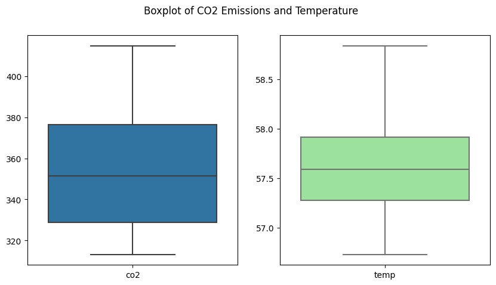

```python
plt.subplots(figsize=(10,5))

plt.subplot(121)
sns.boxplot(data=y[['co2']])

plt.subplot(122)
sns.boxplot(data=y[['temp']], color='lightgreen')

plt.suptitle('Boxplot of CO2 Emissions and Temperature')
plt.show()
```

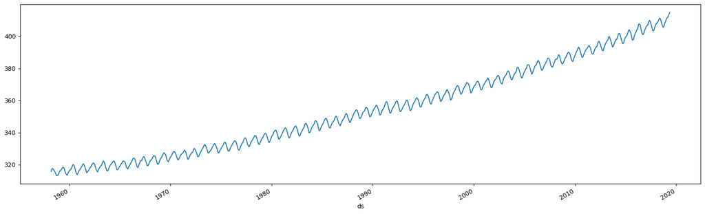

```python
y['co2'].plot(figsize=(20, 6))
```

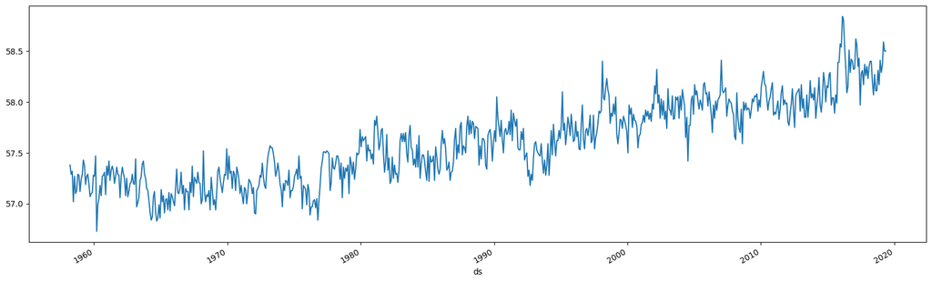

```python
y['temp'].plot(figsize=(20, 6))
```

## Part 2. 35 pts – ARIMA with external regressors

### a. Split Temp into train test. Determine the transformation, seasonal differencing & non seasonal differencing orders if required. Include the following: plot of differenced data, ADF results, kpss results, ACF/PACF plots.

```python
y_train, y_test = temporal_train_test_split(y)
```

```python
y_train.shape
```

```
(551, 2)
```

```python
y_test.shape
```

```
(184, 2)
```

```python
co2_train = y_train['co2']
co2_test = y_test['co2']
```

```python
temp_train = y_train['temp']
temp_test = y_test['temp']
```

```
seasonal differencing
```

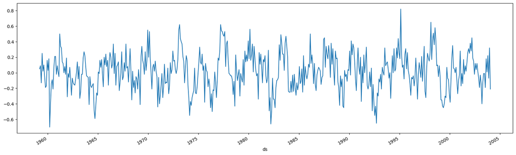

```python
trans_sdiff_data = (temp_train-temp_train.shift(12)).iloc[1:]
trans_sdiff_data.plot(figsize=(20, 6))
```

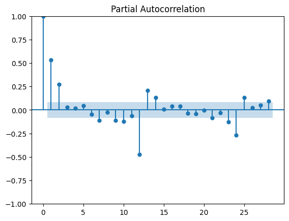

```python
plot_pacf(trans_sdiff_data.dropna())
plt.show()
```

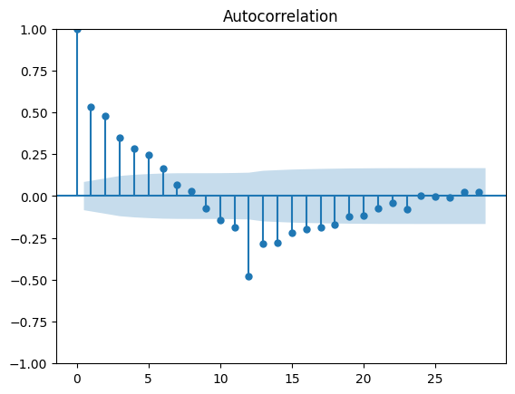

```python
plot_acf(trans_sdiff_data.dropna())
plt.show()
```

```python
def adf_kpss_test(data):
    # ADF test
    result_adf = adfuller(data)
    print('ADF Test:')
    print(f'ADF Statistic: {round(result_adf[0],3)}')
    print(f'p-value: {round(result_adf[1],3)}')
    print(f'Critical Values: {result_adf[4]}')
    #print whether the data is stationary or not at 1% significance level
    if abs(result_adf[0]) > abs(result_adf[4]['1%']) and result_adf[1] < 0.05:
        print('We can reject the null hypothesis at 1% significance level that the data is NOT stationary. The data is likely stationary')
    else:
        print('We cannot reject the null hypothesis at 1% significance level that the data is NOT stationary. The data is likely NOT stationary')

    # KPSS test
    result_kpss = kpss(data, nlags='auto')
    print('\nKPSS Test:')
    print(f'KPSS Statistic: {round(result_kpss[0],3)}')
    print(f'p-value: {round(result_kpss[1],3)}')
    print(f'Critical Values: {result_kpss[3]}')
    #print whether the data is stationary or not at 1% significance level
    if abs(result_kpss[0]) > abs(result_kpss[3]['1%']) and result_kpss[1] < 0.05:
        print('We can reject the null hypothesis at 1% significance level that the data is stationary. The data is likely NOT stationary')
    else:
        print('We cannot reject the null hypothesis at 1% significance level that the data is stationary. The data is likely stationary')

    if result_adf[0] > result_adf[4]['1%'] and result_kpss[0] > result_kpss[3]['1%']:
        print('The ADF and KPSS tests are giving conflicting results.')
```

```python
adf_kpss_test(trans_sdiff_data.dropna())
```

```
ADF Test:
ADF Statistic: -7.25
p-value: 0.0
Critical Values: {'1%': -3.4428672600488066, '5%': -2.8670609714890403, '10%': -2.5697104770975057}
We can reject the null hypothesis at 1% significance level that the data is NOT stationary. The data is likely stationary

KPSS Test:
KPSS Statistic: 0.045
p-value: 0.1
Critical Values: {'10%': 0.347, '5%': 0.463, '2.5%': 0.574, '1%': 0.739}
We cannot reject the null hypothesis at 1% significance level that the data is stationary. The data is likely stationary
```

### b. Fit a SARIMA or ARIMA model based on your examinations. Examine the residuals. Include the following: plot, histogram, ACF, Ljung Box results. Check if auto arima gives you a different order. If this is a better model, examine the residuals of this model.

```python
model = SARIMAX(temp_train, order=(12, 0, 12), seasonal_order=(0,1,0,12))
model_fit = model.fit()
```

[output not shown]

```
 This problem is unconstrained.
```

[output not shown]

```python
print(model_fit.summary())
```

```
                                       SARIMAX Results
=============================================================================================
Dep. Variable:                                  temp   No. Observations:                  551
Model:             SARIMAX(12, 0, 12)x(0, 1, [], 12)   Log Likelihood                 290.456
Date:                               Fri, 05 May 2023   AIC                           -530.913
Time:                                       22:19:54   BIC                           -423.670
Sample:                                            0   HQIC                          -488.967
                                               - 551
Covariance Type:                                 opg
==============================================================================
                 coef    std err          z      P>|z|      [0.025      0.975]
------------------------------------------------------------------------------
ar.L1          0.3368      0.055      6.089      0.000       0.228       0.445
ar.L2          0.2394      0.056      4.249      0.000       0.129       0.350
ar.L3          0.0046      0.055      0.084      0.933      -0.103       0.112
ar.L4          0.1055      0.058      1.812      0.070      -0.009       0.220
ar.L5          0.0619      0.053      1.169      0.242      -0.042       0.166
ar.L6          0.0210      0.054      0.386      0.699      -0.086       0.128
ar.L7         -0.0418      0.049     -0.844      0.399      -0.139       0.055
ar.L8          0.0753      0.056      1.349      0.177      -0.034       0.185
ar.L9         -0.0872      0.055     -1.597      0.110      -0.194       0.020
ar.L10        -0.0232      0.050     -0.467      0.640      -0.121       0.074
ar.L11         0.0258      0.052      0.497      0.619      -0.076       0.128
ar.L12        -0.0503      0.052     -0.961      0.336      -0.153       0.052
ma.L1          0.0394      0.115      0.343      0.731      -0.186       0.264
ma.L2          0.0105      0.077      0.136      0.892      -0.141       0.162
ma.L3          0.0254      0.075      0.338      0.736      -0.122       0.173
ma.L4          0.0389      0.075      0.516      0.606      -0.109       0.187
ma.L5          0.0224      0.098      0.227      0.820      -0.171       0.215
ma.L6          0.0444      0.129      0.345      0.730      -0.208       0.296
ma.L7          0.0413      0.103      0.400      0.689      -0.161       0.243
ma.L8          0.0472      0.080      0.588      0.557      -0.110       0.205
ma.L9          0.0637      0.079      0.810      0.418      -0.090       0.218
ma.L10         0.0580      0.066      0.876      0.381      -0.072       0.188
ma.L11         0.0229      0.107      0.215      0.830      -0.186       0.232
ma.L12        -0.9362      0.138     -6.800      0.000      -1.206      -0.666
sigma2         0.0186      0.003      7.384      0.000       0.014       0.023
===================================================================================
Ljung-Box (L1) (Q):                   0.00   Jarque-Bera (JB):                 4.16
Prob(Q):                              0.97   Prob(JB):                         0.12
Heteroskedasticity (H):               1.09   Skew:                            -0.01
Prob(H) (two-sided):                  0.56   Kurtosis:                         3.43
===================================================================================

Warnings:
[1] Covariance matrix calculated using the outer product of gradients (complex-step).
```

```python
# Return AICc
print("AICc for order " + str(model.order) + str(model.seasonal_order) +": " +str(model_fit.aicc))
```

```
AICc for order (12, 0, 12)(0, 1, 0, 12): -528.3788198310374
```

```python
residuals = model_fit.resid[13:]
```

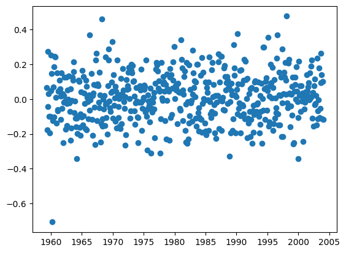

```python
plt.scatter(residuals.index, residuals)
```

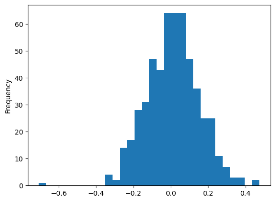

```python
residuals.plot(kind='hist', bins=30)
```

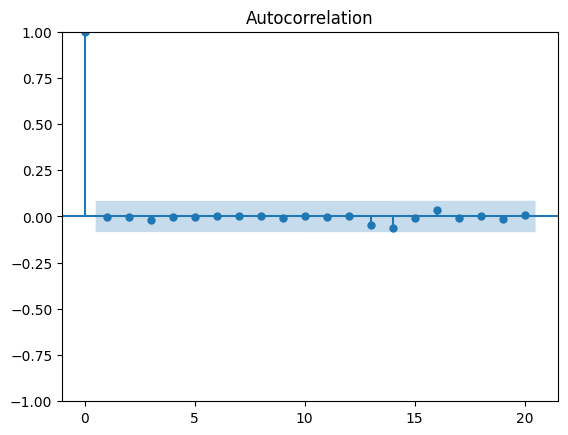

```python
plot_acf(residuals, lags=20)
plt.show()
```

```python
lb_test = acorr_ljungbox(residuals, lags=20)
lb_test
```

|  | lb_stat | lb_pvalue |
| --- | --- | --- |
| 1 | 0.001070 | 0.973899 |
| 2 | 0.002454 | 0.998774 |
| 3 | 0.176178 | 0.981340 |
| 4 | 0.179082 | 0.996223 |
| 5 | 0.189153 | 0.999226 |
| 6 | 0.189174 | 0.999869 |
| 7 | 0.189175 | 0.999979 |
| 8 | 0.189588 | 0.999997 |
| 9 | 0.219867 | 0.999999 |
| 10 | 0.235089 | 1.000000 |
| 11 | 0.238092 | 1.000000 |
| 12 | 0.238092 | 1.000000 |
| 13 | 1.318785 | 0.999980 |
| 14 | 3.316299 | 0.998368 |
| 15 | 3.356692 | 0.999199 |
| 16 | 3.962120 | 0.998967 |
| 17 | 4.025991 | 0.999460 |
| 18 | 4.039454 | 0.999745 |
| 19 | 4.136665 | 0.999862 |
| 20 | 4.175324 | 0.999934 |

Comment: From the plots, histogram we can conclude that the residuals are independently distributed with no significant autocorrelation, which suggests that the SARIMA model is a good fit for the time series data.

```
Using AutoArima
```

```python
model_auto = auto_arima(temp_train, seasonal=True, m=12, trace= True)
model_auto_fit = model_auto.fit(temp_train)
```

```
Performing stepwise search to minimize aic
 ARIMA(2,1,2)(1,0,1)[12] intercept   : AIC=-587.085, Time=0.85 sec
 ARIMA(0,1,0)(0,0,0)[12] intercept   : AIC=-440.190, Time=0.03 sec
 ARIMA(1,1,0)(1,0,0)[12] intercept   : AIC=-544.358, Time=0.11 sec
 ARIMA(0,1,1)(0,0,1)[12] intercept   : AIC=-579.894, Time=0.46 sec
 ARIMA(0,1,0)(0,0,0)[12]             : AIC=-442.169, Time=0.01 sec
 ARIMA(2,1,2)(0,0,1)[12] intercept   : AIC=-589.290, Time=0.77 sec
 ARIMA(2,1,2)(0,0,0)[12] intercept   : AIC=-595.313, Time=0.23 sec
 ARIMA(2,1,2)(1,0,0)[12] intercept   : AIC=-589.652, Time=0.70 sec
 ARIMA(1,1,2)(0,0,0)[12] intercept   : AIC=-577.817, Time=0.06 sec
 ARIMA(2,1,1)(0,0,0)[12] intercept   : AIC=-597.414, Time=0.18 sec
 ARIMA(2,1,1)(1,0,0)[12] intercept   : AIC=-595.231, Time=0.56 sec
 ARIMA(2,1,1)(0,0,1)[12] intercept   : AIC=-595.479, Time=0.84 sec
 ARIMA(2,1,1)(1,0,1)[12] intercept   : AIC=-593.625, Time=1.19 sec
 ARIMA(1,1,1)(0,0,0)[12] intercept   : AIC=-583.297, Time=0.08 sec
 ARIMA(2,1,0)(0,0,0)[12] intercept   : AIC=-555.536, Time=0.05 sec
 ARIMA(3,1,1)(0,0,0)[12] intercept   : AIC=-595.800, Time=0.21 sec
 ARIMA(1,1,0)(0,0,0)[12] intercept   : AIC=-546.277, Time=0.03 sec
 ARIMA(3,1,0)(0,0,0)[12] intercept   : AIC=-575.646, Time=0.09 sec
 ARIMA(3,1,2)(0,0,0)[12] intercept   : AIC=-594.460, Time=0.23 sec
 ARIMA(2,1,1)(0,0,0)[12]             : AIC=-596.104, Time=0.06 sec

Best model:  ARIMA(2,1,1)(0,0,0)[12] intercept
Total fit time: 6.751 seconds
```

```python
print(model_auto_fit.summary())
```

```
                               SARIMAX Results
==============================================================================
Dep. Variable:                      y   No. Observations:                  551
Model:               SARIMAX(2, 1, 1)   Log Likelihood                 303.707
Date:                Fri, 05 May 2023   AIC                           -597.414
Time:                        23:07:10   BIC                           -575.865
Sample:                             0   HQIC                          -588.993
                                - 551
Covariance Type:                  opg
==============================================================================
                 coef    std err          z      P>|z|      [0.025      0.975]
------------------------------------------------------------------------------
intercept      0.0005      0.000      2.353      0.019    7.92e-05       0.001
ar.L1          0.4027      0.045      9.048      0.000       0.315       0.490
ar.L2          0.2499      0.048      5.256      0.000       0.157       0.343
ma.L1         -0.9704      0.013    -72.595      0.000      -0.997      -0.944
sigma2         0.0194      0.001     18.968      0.000       0.017       0.021
===================================================================================
Ljung-Box (L1) (Q):                   0.03   Jarque-Bera (JB):                11.20
Prob(Q):                              0.87   Prob(JB):                         0.00
Heteroskedasticity (H):               1.18   Skew:                             0.03
Prob(H) (two-sided):                  0.27   Kurtosis:                         3.70
===================================================================================

Warnings:
[1] Covariance matrix calculated using the outer product of gradients (complex-step).
```

### Comment:

Based on these criteria, Model 2 has a lower AIC value and a higher log-likelihood value, indicating that it is a better model.

```python
residuals = model_auto_fit.resid()[13:]
```

```python
residuals
```

```
ds
1959-04-15    0.031846
1959-05-15   -0.175296
1959-06-15    0.002869
1959-07-15    0.037499
1959-08-15   -0.082932
                ...
2003-09-15    0.063643
2003-10-15    0.050897
2003-11-15   -0.165669
2003-12-15    0.135830
2004-01-15   -0.044787
Length: 538, dtype: float64
```

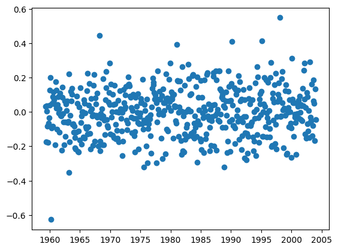

```python
plt.scatter(residuals.index, residuals)
```

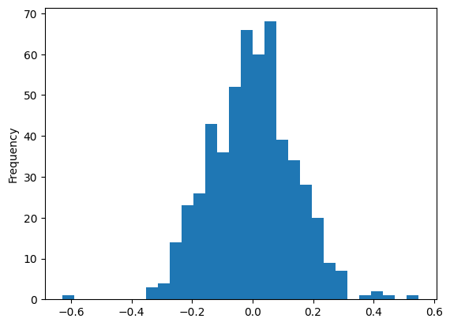

```python
residuals.plot(kind='hist', bins=30)
```

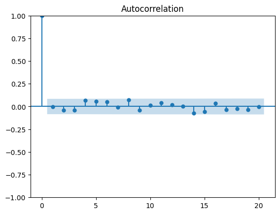

```python
plot_acf(residuals, lags=20)
plt.show()
```

```python
lb_test = acorr_ljungbox(residuals, lags=20)
lb_test
```

|  | lb_stat | lb_pvalue |
| --- | --- | --- |
| 1 | 0.012554 | 0.910789 |
| 2 | 0.805836 | 0.668367 |
| 3 | 1.801812 | 0.614541 |
| 4 | 4.396449 | 0.355003 |
| 5 | 6.202332 | 0.287026 |
| 6 | 7.513870 | 0.275924 |
| 7 | 7.547987 | 0.374132 |
| 8 | 10.311322 | 0.243851 |
| 9 | 11.311108 | 0.254985 |
| 10 | 11.433211 | 0.324777 |
| 11 | 12.338640 | 0.338734 |
| 12 | 12.571062 | 0.400972 |
| 13 | 12.575401 | 0.481117 |
| 14 | 15.476097 | 0.346403 |
| 15 | 17.130527 | 0.311122 |
| 16 | 17.771644 | 0.337438 |
| 17 | 18.390428 | 0.364620 |
| 18 | 18.671889 | 0.412284 |
| 19 | 19.407268 | 0.431004 |
| 20 | 19.416595 | 0.494914 |

Comment: From the plots, histogram we can conclude that the residuals are independently distributed with no significant autocorrelation, which suggests that the SARIMA model is a good fit for the time series data.

### c. Using your best model, predict the test set. Include the following: MAE, MSE, MAPE, sMAPE, MASE. Can use prebuilt functions or calculate by hand.

```python
fh = list(range(1, 1+len(temp_test)))
temp_auto_pred = model_auto_fit.predict(n_periods=len(fh))
temp_pred = model_fit.forecast(steps = len(temp_test))
```

```python
# Calculate MAE and MSE
MAE = mean_absolute_error(temp_test, temp_pred)
MSE = mean_squared_error(temp_test, temp_pred)

# Calculate MAPE and sMAPE
MAPE = MeanAbsolutePercentageError(symmetric=False)(temp_test, temp_pred)
SMAPE = MeanAbsolutePercentageError(symmetric=True)(temp_test, temp_pred)

MASE = MeanAbsoluteScaledError()(temp_test, temp_pred, y_train=temp_train)

# Print the results
print("MAE:", MAE)
print("MSE:", MSE)
print("MAPE:", MAPE)
print("sMAPE:", SMAPE)
print("MASE:", MASE)
```

```
MAE: 0.1724546317857681
MSE: 0.05086730757808922
MAPE: 0.002965215660328378
sMAPE: 0.0029680976008197315
MASE: 1.3511402775238237
```

### d. Refit your best model by adding co2 as an external regressor. Examine the residuals of this model.

```python
model = SARIMAX(temp_train, co2_train, order=(2, 1, 1))
model_fit = model.fit()
```

[output not shown]

```
 This problem is unconstrained.
```

```python
# Return AICc
print("AICc for order " + str(model.order) + str(model.seasonal_order) +": " +str(model_fit.aicc))
```

```
AICc for order (2, 1, 1)(0, 0, 0, 0): -603.5042368319588
```

```python
residuals = model_fit.resid[13:]
```

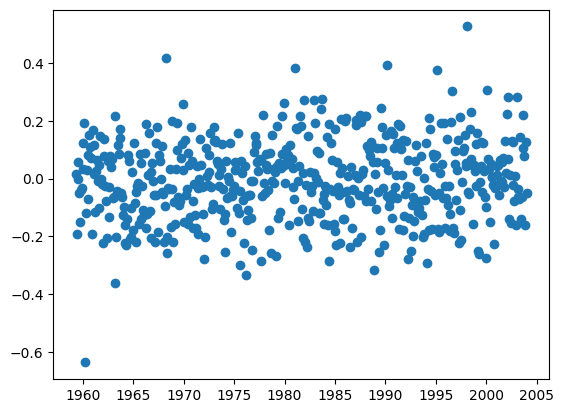

```python
plt.scatter(residuals.index, residuals)
```

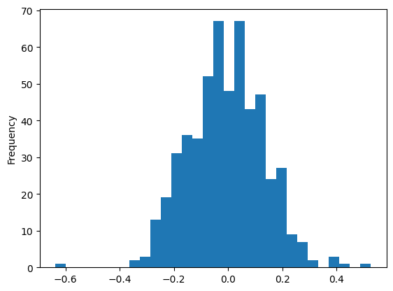

```python
residuals.plot(kind='hist', bins=30)
```

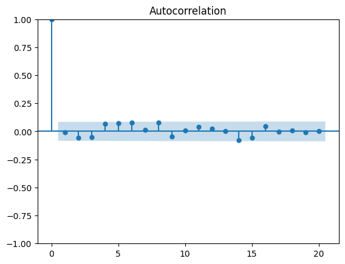

```python
plot_acf(residuals, lags=20)
plt.show()
```

```python
lb_test = acorr_ljungbox(residuals, lags=20)
lb_test
```

|  | lb_stat | lb_pvalue |
| --- | --- | --- |
| 1 | 0.053458 | 0.817152 |
| 2 | 1.789936 | 0.408621 |
| 3 | 3.384600 | 0.336040 |
| 4 | 5.953105 | 0.202678 |
| 5 | 8.932341 | 0.111793 |
| 6 | 12.152861 | 0.058644 |
| 7 | 12.258830 | 0.092362 |
| 8 | 15.551316 | 0.049271 |
| 9 | 16.769661 | 0.052448 |
| 10 | 16.804201 | 0.078810 |
| 11 | 17.783782 | 0.086735 |
| 12 | 18.093861 | 0.112870 |
| 13 | 18.095651 | 0.153921 |
| 14 | 21.399219 | 0.091831 |
| 15 | 23.284626 | 0.078281 |
| 16 | 24.444678 | 0.080232 |
| 17 | 24.458736 | 0.107497 |
| 18 | 24.493761 | 0.139508 |
| 19 | 24.538491 | 0.176300 |
| 20 | 24.548231 | 0.219264 |

### e. Predict the test set. Include the following: MAE, MSE, MAPE, sMAPE, MASE. Can use prebuilt functions or calculate by hand.

```python
forecast = model_fit.forecast(steps=len(temp_test), exog=co2_test)
```

```python
# Calculate MAE and MSE
MAE = mean_absolute_error(temp_test, forecast)
MSE = mean_squared_error(temp_test, forecast)

# Calculate MAPE and sMAPE
MAPE = MeanAbsolutePercentageError(symmetric=False)(temp_test, forecast)
SMAPE = MeanAbsolutePercentageError(symmetric=True)(temp_test, forecast)

MASE = MeanAbsoluteScaledError()(temp_test, forecast, y_train=temp_train)

# Print the results
print("MAE:", MAE)
print("MSE:", MSE)
print("MAPE:", MAPE)
print("sMAPE:", SMAPE)
print("MASE:", MASE)
```

```
MAE: 0.14542174728389237
MSE: 0.035239780472337834
MAPE: 0.002505375206349828
sMAPE: 0.002503188646619127
MASE: 1.1393441738766494
```

### Comment:

Comparing the model performance metrics, we can see that the model with exogenous variables has lower MAE, MSE, MAPE, sMAPE, and MASE values. This suggests that the model with exogenous variables is performing better than the model without exogenous variables.

## Part 3. 35 pts – Prophet with additional regressors

### a. Using the same train test split as part 2, fit a prophet model to your NON-differenced training set. Examine the residuals. Using the predicted values and y train, calculate the following: MAE, MSE, MAPE, sMAPE, MASE. Can use prebuilt functions or calculate by hand.

```python
co2 = pd.read_csv('hw5_data_co2.csv', index_col=0, parse_dates=True)
temp = pd.read_csv('hw5_data_temp.csv', index_col=0, parse_dates=True)
```

```python
df = pd.merge_asof(co2, temp, on='ds', direction='nearest')
```

```python
df['y'] = df['temp']
```

```python
train = df.iloc[:551]
test = df.iloc[551:]
```

```python
train.shape
```

```
(551, 4)
```

```python
test.shape
```

```
(184, 4)
```

```python
model = Prophet()
model_fit = model.fit(train)
```

```
INFO:fbprophet:Disabling weekly seasonality. Run prophet with weekly_seasonality=True to override this.
INFO:fbprophet:Disabling daily seasonality. Run prophet with daily_seasonality=True to override this.
```

[output not shown]

```python
future_data = model.make_future_dataframe(periods=len(test), freq='m')
```

```python
forecast_data = model.predict(future_data)
forecast_data
```

|  | ds | trend | yhat_lower | yhat_upper | trend_lower | trend_upper | additive_terms | additive_terms_lower | additive_terms_upper | yearly | yearly_lower | yearly_upper | multiplicative_terms | multiplicative_terms_lower | multiplicative_terms_upper | yhat |
| --- | --- | --- | --- | --- | --- | --- | --- | --- | --- | --- | --- | --- | --- | --- | --- | --- |
| 0 | 1958-03-15 | 57.213162 | 57.080815 | 57.480468 | 57.213162 | 57.213162 | 0.062452 | 0.062452 | 0.062452 | 0.062452 | 0.062452 | 0.062452 | 0.0 | 0.0 | 0.0 | 57.275615 |
| 1 | 1958-04-15 | 57.213550 | 57.053411 | 57.434195 | 57.213550 | 57.213550 | 0.031649 | 0.031649 | 0.031649 | 0.031649 | 0.031649 | 0.031649 | 0.0 | 0.0 | 0.0 | 57.245199 |
| 2 | 1958-05-15 | 57.213924 | 57.039609 | 57.414728 | 57.213924 | 57.213924 | 0.020318 | 0.020318 | 0.020318 | 0.020318 | 0.020318 | 0.020318 | 0.0 | 0.0 | 0.0 | 57.234243 |
| 3 | 1958-06-15 | 57.214312 | 57.053835 | 57.409825 | 57.214312 | 57.214312 | 0.007226 | 0.007226 | 0.007226 | 0.007226 | 0.007226 | 0.007226 | 0.0 | 0.0 | 0.0 | 57.221538 |
| 4 | 1958-07-15 | 57.214687 | 57.054200 | 57.416053 | 57.214687 | 57.214687 | 0.018814 | 0.018814 | 0.018814 | 0.018814 | 0.018814 | 0.018814 | 0.0 | 0.0 | 0.0 | 57.233500 |
| ... | ... | ... | ... | ... | ... | ... | ... | ... | ... | ... | ... | ... | ... | ... | ... | ... |
| 730 | 2018-12-31 | 58.494475 | 55.394739 | 59.732986 | 56.365116 | 60.734380 | -0.982040 | -0.982040 | -0.982040 | -0.982040 | -0.982040 | -0.982040 | 0.0 | 0.0 | 0.0 | 57.512435 |
| 731 | 2019-01-31 | 58.497389 | 56.575136 | 61.060057 | 56.342786 | 60.750140 | 0.293847 | 0.293847 | 0.293847 | 0.293847 | 0.293847 | 0.293847 | 0.0 | 0.0 | 0.0 | 58.791236 |
| 732 | 2019-02-28 | 58.500021 | 56.965044 | 61.348306 | 56.329683 | 60.758782 | 0.589854 | 0.589854 | 0.589854 | 0.589854 | 0.589854 | 0.589854 | 0.0 | 0.0 | 0.0 | 59.089876 |
| 733 | 2019-03-31 | 58.502936 | 56.851214 | 61.345415 | 56.331683 | 60.786039 | 0.541187 | 0.541187 | 0.541187 | 0.541187 | 0.541187 | 0.541187 | 0.0 | 0.0 | 0.0 | 59.044122 |
| 734 | 2019-04-30 | 58.505756 | 55.980507 | 60.520911 | 56.314583 | 60.808365 | -0.343909 | -0.343909 | -0.343909 | -0.343909 | -0.343909 | -0.343909 | 0.0 | 0.0 | 0.0 | 58.161847 |

735 rows × 16 columns

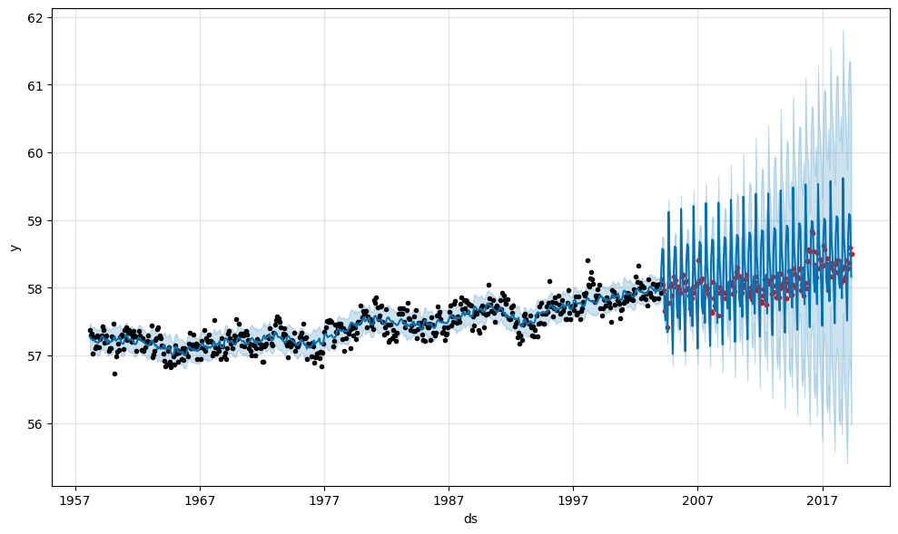

```python
p = model.plot(forecast_data)
plt.scatter(pd.to_datetime(test['ds']),pd.to_numeric(test['y']), color='r', marker='.')
plt.show()
```

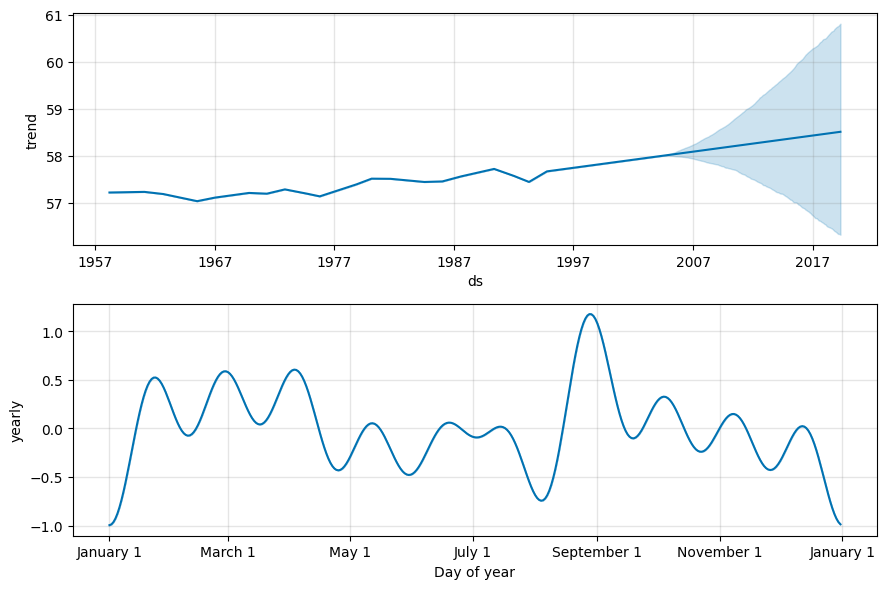

```python
p = model.plot_components(forecast_data)
```

```python
df['residuals'] = df['y'].values - forecast_data['yhat'].values
residuals = df['residuals'].iloc[:551]
```

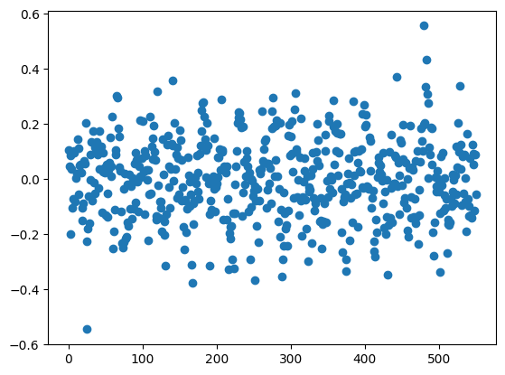

```python
plt.scatter(residuals.index, residuals)
```

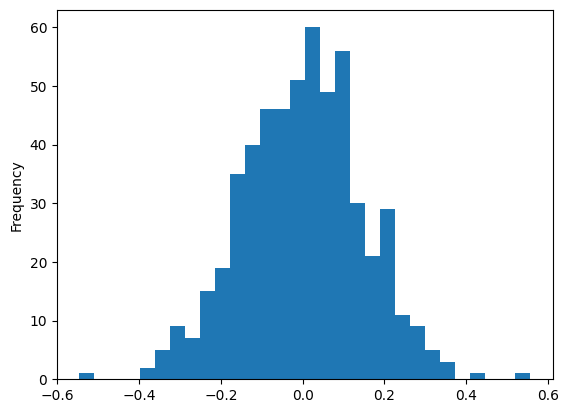

```python
residuals.plot(kind='hist', bins=30)
```

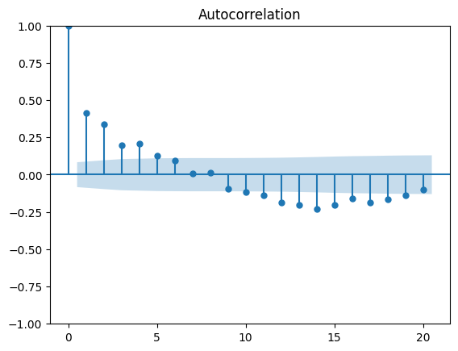

```python
plot_acf(residuals, lags=20)
plt.show()
```

```python
lb_test = acorr_ljungbox(residuals, lags=20)
lb_test
```

|  | lb_stat | lb_pvalue |
| --- | --- | --- |
| 1 | 93.671254 | 3.725321e-22 |
| 2 | 157.292053 | 6.989800e-35 |
| 3 | 179.085443 | 1.389842e-38 |
| 4 | 202.718527 | 9.780438e-43 |
| 5 | 211.772232 | 8.590216e-44 |
| 6 | 216.576193 | 5.587652e-44 |
| 7 | 216.605112 | 3.466296e-43 |
| 8 | 216.676202 | 1.939249e-42 |
| 9 | 221.447898 | 1.038057e-42 |
| 10 | 228.801959 | 1.531477e-43 |
| 11 | 239.786819 | 3.829536e-45 |
| 12 | 259.553547 | 1.388012e-48 |
| 13 | 283.109827 | 8.155180e-53 |
| 14 | 313.700339 | 1.633957e-58 |
| 15 | 337.740232 | 7.665524e-63 |
| 16 | 352.464382 | 3.169535e-65 |
| 17 | 372.425494 | 1.057940e-68 |
| 18 | 388.529192 | 2.247765e-71 |
| 19 | 399.227970 | 6.346824e-73 |
| 20 | 404.957042 | 1.914195e-73 |

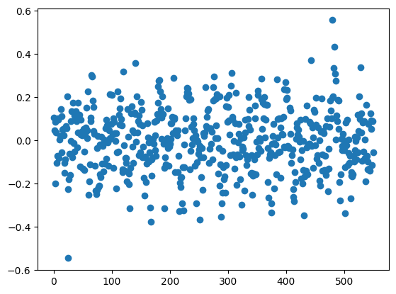

```python
plt.scatter(residuals.index, residuals)
```

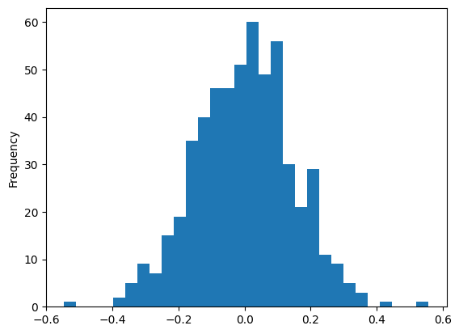

```python
residuals.plot(kind='hist', bins=30)
```

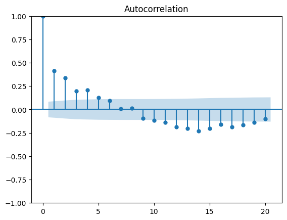

```python
plot_acf(residuals, lags=20)
plt.show()
```

```python
lb_test = acorr_ljungbox(residuals, lags=20)
lb_test
```

|  | lb_stat | lb_pvalue |
| --- | --- | --- |
| 1 | 93.671254 | 3.725321e-22 |
| 2 | 157.292053 | 6.989800e-35 |
| 3 | 179.085443 | 1.389842e-38 |
| 4 | 202.718527 | 9.780438e-43 |
| 5 | 211.772232 | 8.590216e-44 |
| 6 | 216.576193 | 5.587652e-44 |
| 7 | 216.605112 | 3.466296e-43 |
| 8 | 216.676202 | 1.939249e-42 |
| 9 | 221.447898 | 1.038057e-42 |
| 10 | 228.801959 | 1.531477e-43 |
| 11 | 239.786819 | 3.829536e-45 |
| 12 | 259.553547 | 1.388012e-48 |
| 13 | 283.109827 | 8.155180e-53 |
| 14 | 313.700339 | 1.633957e-58 |
| 15 | 337.740232 | 7.665524e-63 |
| 16 | 352.464382 | 3.169535e-65 |
| 17 | 372.425494 | 1.057940e-68 |
| 18 | 388.529192 | 2.247765e-71 |
| 19 | 399.227970 | 6.346824e-73 |
| 20 | 404.957042 | 1.914195e-73 |

### Comment:

We can observe some autocorrelation from both the acf plot and Ljung test.

```python
# Calculate MAE and MSE
MAE = mean_absolute_error(df['y'][551:], forecast_data['yhat'][551:])
MSE = mean_squared_error(df['y'][551:], forecast_data['yhat'][551:])

# Calculate MAPE and sMAPE
MAPE = MeanAbsolutePercentageError(symmetric=False)(df['y'][551:], forecast_data['yhat'][551:])
SMAPE = MeanAbsolutePercentageError(symmetric=True)(df['y'][551:], forecast_data['yhat'][551:])

MASE = MeanAbsoluteScaledError()(df['y'][551:], forecast_data['yhat'][551:], y_train=temp_train)

# Print the results
print("MAE:", MAE)
print("MSE:", MSE)
print("MAPE:", MAPE)
print("sMAPE:", SMAPE)
print("MASE:", MASE)
```

```
MAE: 0.4722172488770444
MSE: 0.35867533709882965
MAPE: 0.00813019154115874
sMAPE: 0.008105570363604092
MASE: 3.6997077903472135
```

### b. Adjust seasonality, changepoint priors or other methods to see if you can create a better fit model. Examine the residuals. Using the predicted values and y train, calculate the following: MAE, MSE, MAPE, sMAPE, MASE. Can use prebuilt functions or calculate by hand.

```python
cutoffs = pd.to_datetime(['1975-02-15', '1985-02-15', '1995-02-15'])
```

```python
param_grid = {
    'seasonality_mode': ['additive' , 'multiplicative'],
    'changepoint_prior_scale': [0.001, 0.01, 0.1, 0.5],
    'seasonality_prior_scale': [0.01, 0.1, 1.0, 10.0],
    'holidays_prior_scale': [0.01, 0.1, 1.0, 10.0],
}

# Generate all combinations of parameters
all_params = [dict(zip(param_grid.keys(), v)) for v in itertools.product(*param_grid.values())]
rmses = []  # Store the RMSEs for each params here

# Use cross validation to evaluate all parameters
for params in all_params:
    m = Prophet(**params).fit(train)  # Fit model with given params
    df_cv = cross_validation(m, cutoffs=cutoffs, horizon='30 days', parallel="processes")
    df_p = performance_metrics(df_cv, rolling_window=1)
    rmses.append(df_p['rmse'].values[0])
```

```python
# Find the best parameters
tuning_results = pd.DataFrame(all_params)
tuning_results['rmse'] = rmses
tuning_results.sort_values('rmse')
```

|  | seasonality_mode | changepoint_prior_scale | seasonality_prior_scale | holidays_prior_scale | rmse |
| --- | --- | --- | --- | --- | --- |
| 88 | multiplicative | 0.01 | 1.00 | 0.01 | 0.047638 |
| 90 | multiplicative | 0.01 | 1.00 | 1.00 | 0.047638 |
| 91 | multiplicative | 0.01 | 1.00 | 10.00 | 0.047638 |
| 89 | multiplicative | 0.01 | 1.00 | 0.10 | 0.047638 |
| 31 | additive | 0.01 | 10.00 | 10.00 | 0.049246 |
| ... | ... | ... | ... | ... | ... |
| 63 | additive | 0.50 | 10.00 | 10.00 | 0.083664 |
| 115 | multiplicative | 0.50 | 0.01 | 10.00 | 0.083720 |
| 113 | multiplicative | 0.50 | 0.01 | 0.10 | 0.083720 |
| 112 | multiplicative | 0.50 | 0.01 | 0.01 | 0.083720 |
| 114 | multiplicative | 0.50 | 0.01 | 1.00 | 0.083720 |

128 rows × 5 columns

```python
# Initialize the model
model_tunned = Prophet(
    seasonality_mode='multiplicative',
    seasonality_prior_scale=1,
    holidays_prior_scale=10,
    changepoint_prior_scale=0.01,
)

# Add seasonality
model_tunned.add_seasonality(
    name='yearly',
    period=12,
    fourier_order=5,
    prior_scale=1
)

# Fit the model
model_tunned.fit(train)
```

```
INFO:fbprophet:Found custom seasonality named 'yearly', disabling built-in 'yearly' seasonality.
INFO:fbprophet:Disabling weekly seasonality. Run prophet with weekly_seasonality=True to override this.
INFO:fbprophet:Disabling daily seasonality. Run prophet with daily_seasonality=True to override this.
```

[output not shown]

```
<fbprophet.forecaster.Prophet at 0x175790760>
```

```python
forecast_data = model_tunned.predict(future_data)
forecast_data
```

|  | ds | trend | yhat_lower | yhat_upper | trend_lower | trend_upper | multiplicative_terms | multiplicative_terms_lower | multiplicative_terms_upper | yearly | yearly_lower | yearly_upper | additive_terms | additive_terms_lower | additive_terms_upper | yhat |
| --- | --- | --- | --- | --- | --- | --- | --- | --- | --- | --- | --- | --- | --- | --- | --- | --- |
| 0 | 1958-03-15 | 57.258715 | 57.073357 | 57.495237 | 57.258715 | 57.258715 | 0.000533 | 0.000533 | 0.000533 | 0.000533 | 0.000533 | 0.000533 | 0.0 | 0.0 | 0.0 | 57.289235 |
| 1 | 1958-04-15 | 57.256955 | 57.017207 | 57.462630 | 57.256955 | 57.256955 | -0.000046 | -0.000046 | -0.000046 | -0.000046 | -0.000046 | -0.000046 | 0.0 | 0.0 | 0.0 | 57.254326 |
| 2 | 1958-05-15 | 57.255252 | 57.047960 | 57.473880 | 57.255252 | 57.255252 | -0.000045 | -0.000045 | -0.000045 | -0.000045 | -0.000045 | -0.000045 | 0.0 | 0.0 | 0.0 | 57.252670 |
| 3 | 1958-06-15 | 57.253492 | 57.009694 | 57.447942 | 57.253492 | 57.253492 | -0.000455 | -0.000455 | -0.000455 | -0.000455 | -0.000455 | -0.000455 | 0.0 | 0.0 | 0.0 | 57.227444 |
| 4 | 1958-07-15 | 57.251789 | 57.070300 | 57.499053 | 57.251789 | 57.251789 | 0.000473 | 0.000473 | 0.000473 | 0.000473 | 0.000473 | 0.000473 | 0.0 | 0.0 | 0.0 | 57.278870 |
| ... | ... | ... | ... | ... | ... | ... | ... | ... | ... | ... | ... | ... | ... | ... | ... | ... |
| 730 | 2018-12-31 | 58.527660 | 58.182749 | 58.823252 | 58.268371 | 58.750028 | -0.000261 | -0.000261 | -0.000261 | -0.000261 | -0.000261 | -0.000261 | 0.0 | 0.0 | 0.0 | 58.512403 |
| 731 | 2019-01-31 | 58.530710 | 58.200138 | 58.822477 | 58.270460 | 58.755098 | -0.000045 | -0.000045 | -0.000045 | -0.000045 | -0.000045 | -0.000045 | 0.0 | 0.0 | 0.0 | 58.528070 |
| 732 | 2019-02-28 | 58.533464 | 58.213042 | 58.854052 | 58.271015 | 58.759526 | 0.000319 | 0.000319 | 0.000319 | 0.000319 | 0.000319 | 0.000319 | 0.0 | 0.0 | 0.0 | 58.552136 |
| 733 | 2019-03-31 | 58.536514 | 58.235633 | 58.886942 | 58.271629 | 58.764379 | 0.000533 | 0.000533 | 0.000533 | 0.000533 | 0.000533 | 0.000533 | 0.0 | 0.0 | 0.0 | 58.567715 |
| 734 | 2019-04-30 | 58.539465 | 58.183640 | 58.825862 | 58.270841 | 58.769368 | -0.000261 | -0.000261 | -0.000261 | -0.000261 | -0.000261 | -0.000261 | 0.0 | 0.0 | 0.0 | 58.524206 |

735 rows × 16 columns

```python
residuals = df['y'] - forecast_data['yhat']
residuals = pd.DataFrame({'residuals':residuals}, index=df.index)
residuals = residuals[:551]
```

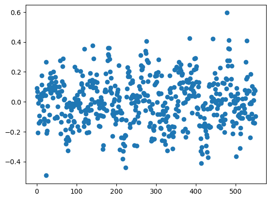

```python
plt.scatter(residuals.index, residuals)
```

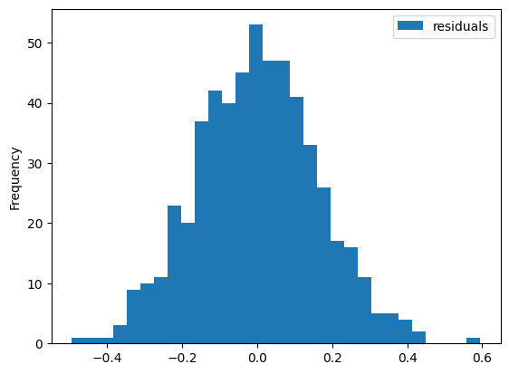

```python
residuals.plot(kind='hist', bins=30)
```

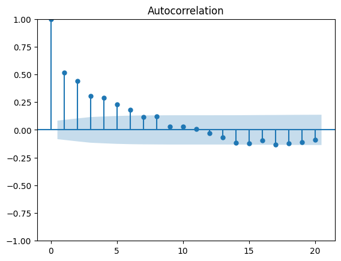

```python
plot_acf(residuals, lags=20)
plt.show()
```

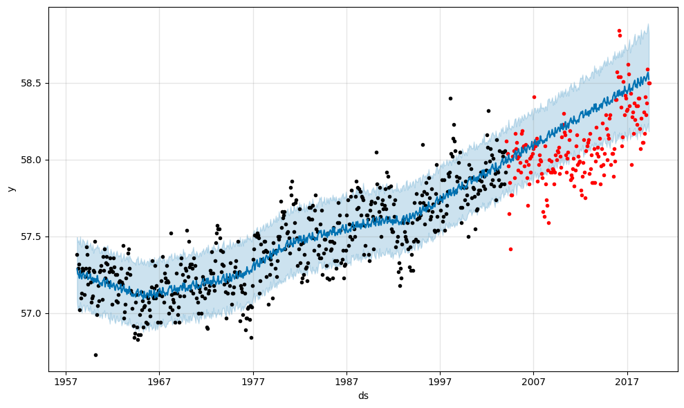

```python
p = model.plot(forecast_data)
plt.scatter(pd.to_datetime(test['ds']),pd.to_numeric(test['y']), color='r', marker='.')
plt.show()
```

```python
# Calculate MAE and MSE
MAE = mean_absolute_error(df['y'][551:], forecast_data['yhat'][551:])
MSE = mean_squared_error(df['y'][551:], forecast_data['yhat'][551:])

# Calculate MAPE and sMAPE
MAPE = MeanAbsolutePercentageError(symmetric=False)(df['y'][551:], forecast_data['yhat'][551:])
SMAPE = MeanAbsolutePercentageError(symmetric=True)(df['y'][551:], forecast_data['yhat'][551:])

MASE = MeanAbsoluteScaledError()(df['y'][551:], forecast_data['yhat'][551:], y_train=temp_train)

# Print the results
print("MAE:", MAE)
print("MSE:", MSE)
print("MAPE:", MAPE)
print("sMAPE:", SMAPE)
print("MASE:", MASE)
```

```
MAE: 0.21536319638904458
MSE: 0.06724500828659608
MAPE: 0.003712871888542175
sMAPE: 0.003703858716108737
MASE: 1.6873184902275569
```

### c. Using your best prophet model, include co2 as an external regressor. Predict the test set. Include the following: MAE, MSE, MAPE, sMAPE, MASE. Can use prebuilt functions or calculate by hand.

```python
model2 = Prophet(
    seasonality_mode='multiplicative',
    seasonality_prior_scale=1,
    holidays_prior_scale=10,
    changepoint_prior_scale=0.01,
)

# Add seasonality
model2.add_seasonality(
    name='yearly',
    period=12,
    fourier_order=5,
    prior_scale=1
)

model2.add_regressor('co2')

model2.fit(train)
```

```
INFO:fbprophet:Found custom seasonality named 'yearly', disabling built-in 'yearly' seasonality.
INFO:fbprophet:Disabling weekly seasonality. Run prophet with weekly_seasonality=True to override this.
INFO:fbprophet:Disabling daily seasonality. Run prophet with daily_seasonality=True to override this.
```

[output not shown]

```
<fbprophet.forecaster.Prophet at 0x29661ad90>
```

```python
future_data['co2'] = df['co2']
forecast_data2 = model2.predict(future_data)
forecast_data2
```

|  | ds | trend | yhat_lower | yhat_upper | trend_lower | trend_upper | co2 | co2_lower | co2_upper | extra_regressors_multiplicative | ... | multiplicative_terms | multiplicative_terms_lower | multiplicative_terms_upper | yearly | yearly_lower | yearly_upper | additive_terms | additive_terms_lower | additive_terms_upper | yhat |
| --- | --- | --- | --- | --- | --- | --- | --- | --- | --- | --- | --- | --- | --- | --- | --- | --- | --- | --- | --- | --- | --- |
| 0 | 1958-03-15 | 57.643874 | 57.085075 | 57.493470 | 57.643874 | 57.643874 | -0.006692 | -0.006692 | -0.006692 | -0.006692 | ... | -0.006178 | -0.006178 | -0.006178 | 0.000514 | 0.000514 | 0.000514 | 0.0 | 0.0 | 0.0 | 57.287750 |
| 1 | 1958-04-15 | 57.641389 | 57.091378 | 57.482867 | 57.641389 | 57.641389 | -0.006234 | -0.006234 | -0.006234 | -0.006234 | ... | -0.006302 | -0.006302 | -0.006302 | -0.000068 | -0.000068 | -0.000068 | 0.0 | 0.0 | 0.0 | 57.278131 |
| 2 | 1958-05-15 | 57.638985 | 57.068386 | 57.485939 | 57.638985 | 57.638985 | -0.006218 | -0.006218 | -0.006218 | -0.006218 | ... | -0.006274 | -0.006274 | -0.006274 | -0.000056 | -0.000056 | -0.000056 | 0.0 | 0.0 | 0.0 | 57.277330 |
| 3 | 1958-06-15 | 57.636501 | 57.012852 | 57.448682 | 57.636501 | 57.636501 | -0.006434 | -0.006434 | -0.006434 | -0.006434 | ... | -0.006883 | -0.006883 | -0.006883 | -0.000449 | -0.000449 | -0.000449 | 0.0 | 0.0 | 0.0 | 57.239761 |
| 4 | 1958-07-15 | 57.634096 | 57.070380 | 57.471076 | 57.634096 | 57.634096 | -0.006650 | -0.006650 | -0.006650 | -0.006650 | ... | -0.006152 | -0.006152 | -0.006152 | 0.000498 | 0.000498 | 0.000498 | 0.0 | 0.0 | 0.0 | 57.279514 |
| ... | ... | ... | ... | ... | ... | ... | ... | ... | ... | ... | ... | ... | ... | ... | ... | ... | ... | ... | ... | ... | ... |
| 730 | 2018-12-31 | 57.622482 | 58.373456 | 58.919364 | 57.434130 | 57.798707 | 0.018255 | 0.018255 | 0.018255 | 0.018255 | ... | 0.017972 | 0.017972 | 0.017972 | -0.000283 | -0.000283 | -0.000283 | 0.0 | 0.0 | 0.0 | 58.658052 |
| 731 | 2019-01-31 | 57.623338 | 58.398293 | 58.961475 | 57.434035 | 57.801767 | 0.018448 | 0.018448 | 0.018448 | 0.018448 | ... | 0.018392 | 0.018392 | 0.018392 | -0.000056 | -0.000056 | -0.000056 | 0.0 | 0.0 | 0.0 | 58.683151 |
| 732 | 2019-02-28 | 57.624111 | 58.422094 | 58.970839 | 57.433950 | 57.804223 | 0.018538 | 0.018538 | 0.018538 | 0.018538 | ... | 0.018849 | 0.018849 | 0.018849 | 0.000311 | 0.000311 | 0.000311 | 0.0 | 0.0 | 0.0 | 58.710246 |
| 733 | 2019-03-31 | 57.624967 | 58.456234 | 59.039351 | 57.433671 | 57.806460 | 0.018933 | 0.018933 | 0.018933 | 0.018933 | ... | 0.019447 | 0.019447 | 0.019447 | 0.000514 | 0.000514 | 0.000514 | 0.0 | 0.0 | 0.0 | 58.745626 |
| 734 | 2019-04-30 | 57.625796 | 58.453417 | 59.017297 | 57.433139 | 57.808552 | 0.019279 | 0.019279 | 0.019279 | 0.019279 | ... | 0.018996 | 0.018996 | 0.018996 | -0.000283 | -0.000283 | -0.000283 | 0.0 | 0.0 | 0.0 | 58.720456 |

735 rows × 22 columns

```python
residuals = df['y'] - forecast_data2['yhat']
residuals2 = pd.DataFrame({'residuals':residuals}, index=df.index)
residuals2 = residuals[:551]
```

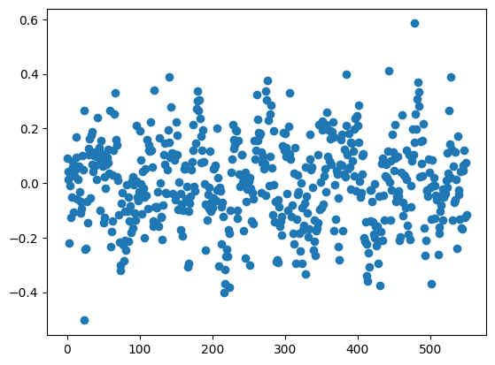

```python
plt.scatter(residuals2.index, residuals2)
```

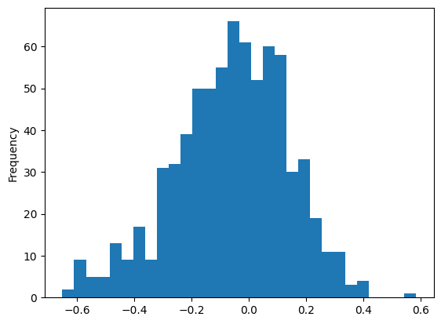

```python
residuals.plot(kind='hist', bins=30)
```

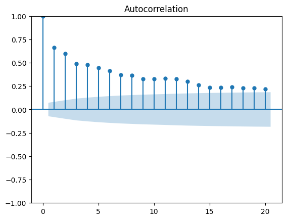

```python
plot_acf(residuals, lags=20)
plt.show()
```

```python
# Calculate MAE and MSE
MAE = mean_absolute_error(df['y'][551:], forecast_data2['yhat'][551:])
MSE = mean_squared_error(df['y'][551:], forecast_data2['yhat'][551:])

# Calculate MAPE and sMAPE
MAPE = MeanAbsolutePercentageError(symmetric=False)(df['y'][551:], forecast_data2['yhat'][551:])
SMAPE = MeanAbsolutePercentageError(symmetric=True)(df['y'][551:], forecast_data2['yhat'][551:])

MASE = MeanAbsoluteScaledError()(df['y'][551:], forecast_data2['yhat'][551:], y_train=temp_train)

# Print the results
print("MAE:", MAE)
print("MSE:", MSE)
print("MAPE:", MAPE)
print("sMAPE:", SMAPE)
print("MASE:", MASE)
```

```
MAE: 0.267901023287893
MSE: 0.09893427471365963
MAPE: 0.004617623976493979
sMAPE: 0.004603486142819887
MASE: 2.0989396411444603
```

### Comment:

Adding additional regressor didn't improve model performance.

### d. Give a summary of your modeling in prophet. What improved the model, what made the fit worse. Give your reasonings why this would happen given the patterns in the data.

I found that changing the seasonality_mode to 'multiplicative' improved the model, as it was able to better capture the non-linear relationship between the seasonal components and the trend. This was especially useful as the amplitude of the seasonal effect varied with the level of the trend. Additionally, including seasonality as a component in the model helped with the model performance.

On the other hand, larger changepoint_prior_scale values can result in a model that is too rigid and unable to capture important changes in the trend. The optimal value for changepoint_prior_scale will depend on the specific dataset and should be chosen through cross-validation.

Regarding the addition of an additional regressor 'co2', it is possible that this variable was not significantly correlated with the target variable 'temp', resulting in a negative impact on the model performance. However, it is also possible that the inclusion of the 'co2' variable introduced multicollinearity or overfitting to the model, leading to a decrease in performance. Therefore, it is important to carefully choose the regressors to include in the model based on domain knowledge and statistical significance tests.

## Part 4. 10 pts – conclusion

Data characteristics: ARIMA models work well when the data follows a stationary process, meaning that the statistical properties of the data remain constant over time. If the data has a clear trend and/or seasonality, then Prophet's ability to capture these patterns may be limited.

Model assumptions: ARIMA models have fewer assumptions compared to Prophet. For example, Prophet assumes that the seasonal pattern is fixed and does not change over time, whereas ARIMA models can handle time-varying patterns.

Model tuning: It's possible that the ARIMA model was better tuned for this particular dataset compared to the Prophet model. ARIMA models have several hyperparameters that can be tuned to optimize the model performance, including the order of differencing, AR and MA terms, and the inclusion of exogenous variables.

Sample size: The sample size of the dataset may also be a factor. ARIMA models tend to work better for smaller sample sizes, whereas Prophet may be more suitable for larger datasets.

### d. If you had this data for 100 locations (different pairs of time series), how would you approach modeling this data?

If I had this data for 100 locations, I would approach modeling the data in a similar way as for a single pair of time series, but with some additional considerations:

Data exploration: I would explore each pair of time series separately to identify patterns and potential outliers.

Data processing: I would preprocess the data for each pair of time series separately, including missing value imputation, normalization, and detrending.

Model selection: I would test multiple models, including ARIMA, SARIMA, and Prophet, for each pair of time series and compare their performance using statistical metrics and visual inspection.

Model combination: Once I have identified the best models for each pair of time series, I would combine them using an appropriate approach, such as a hierarchical model, to account for the dependencies between the time series.

Cross-validation: I would use cross-validation to evaluate the performance of the models and ensure that they generalize well to new data.

Forecasting: Finally, I would use the selected models to make forecasts for each pair of time series and evaluate the results using appropriate metrics.